# Mission: Iconic Reefs and National Coral Reef Monitoring Program Benthic Analyses

Summary Report for 2022 and 2024

Published

February 27, 2026

[figure not shown]

[figure not shown]

Authors:  
[Nicole Krampitz](https://github.com/nkrampitz/MIR-Krampitz)<sup>1</sup>, Dione Swanson<sup>2,3</sup>, Julia Mateski<sup>1</sup>, Lexie Sturm<sup>4</sup>, Shay Viehman<sup>4</sup>  
<sup>1</sup> CSS, Inc. under contract to NOAA National Ocean Service, National Centers for Coastal Ocean Science  
<sup>2</sup> NOAA National Marine Fisheries Service, Southeast Fisheries Science Center  
<sup>3</sup> University of Miami, Cooperative Institute for Marine and Atmospheric Studies  
<sup>4</sup> NOAA National Ocean Service, National Centers for Coastal Ocean Science

## 1 Introduction

[Mission: Iconic Reefs](https://www.fisheries.noaa.gov/southeast/habitat-conservation/restoring-seven-iconic-reefs-mission-recover-coral-reefs-florida-keys) (M:IR) is a multi-institutional initiative designed to restore ecological function and biodiversity across key reef sites in the Florida Keys. Led by NOAA in collaboration with federal, state, academic, institutional, and non-profit partners, M:IR targets nearly three million square feet of reef at seven key coral reefs in the Florida Keys National Marine Sanctuary (FKNMS): Carysfort (North and South), Horseshoe Reef, Cheeca Rocks, Sombrero Reef, Newfound Harbor, Looe Key, and Eastern Dry Rocks (Figure 1). Across these reefs, M:IR aims to restore coral cover to an average of 25% within suitable habitats across the seven sites – an initiative unparalleled in scope and scale that will require hundreds of thousands of coral restoration outplants and over a decade of phased intervention.

[figure not shown]

Figure 1: Map of the Florida Keys showing the sites of Mission: Iconic Reefs

These Iconic reefs were selected for restoration due to their diversity in reef types, levels of anthropogenic disturbances, initial coral cover, connectivity to other habitat types, geographic distribution, and cultural significance. Restoration progress at these reefs is informed by ongoing monitoring of coral reef benthic communities and coral populations at M:IR sites using a range of metrics, such as coral cover, size structure, mortality prevalence, and diversity. Such multi-metric monitoring is essential to evaluating whether current restoration practices are effective in establishing and maintaining a healthy coral reef, as restoration ‘success’ encompasses a range of ecological and management metrics rather than a single measurement (e.g., coral cover) (Goergen et al., 2020).

In addition to monitoring within the M:IR reefs, it is also important to assess the surrounding reefs in the Florida Keys to interpret restoration progress. The National Coral Reef Monitoring Program (NCRMP), which conducts standardized reef assessments across the Florida Keys on a biennial basis, provides a solid framework for comparison. To align with this program, the M:IR team applied NCRMP survey methodology within its Iconic Reefs in 2022 and 2024 to complement NCRMP surveys. These surveys focused on shallow (<30 m), hard-bottom reef habitats, using a stratified-random, one-stage design within 50 m × 50 m grid cells to ensure representative sampling across depth and rugosity strata (Ault et al., 2021). The survey design ensures that survey sites are allocated by cross-shelf zone, rugosity type, and depth strata, with sites distributed around the Florida Keys from nearshore to offshore to a maximum depth of 30 m. The NCRMP sample grid was spatially joined with the seven distinct M:IR zones (Figure 1). Survey sites were proportionally allocated within NCRMP strata to maintain consistent representation across habitats.

## 2 Data Analyses

To allow for direct comparisons of benthic communities inside the M:IR restoration areas with control, non-restored areas across the Florida Keys reefs, the NCRMP dataset was restricted to strata types and depth zones (0-12 m) found within M:IR sites. Statistical comparisons were conducted using a two-tailed t-test between M:IR and NCRMP estimates for each survey year (2022 or 2024) and between years for M:IR and NCRMP. This report focuses on coral populations and benthic community metrics; a separate [report](https://rob-harper.github.io/MissionIconicReef) can be found for fish population assessments (Blondeau et al., 2025).

NCRMP analyses scripts for corals and benthic communities are open source and available at [NCRMP Benthic R package](https://github.com/MSE-NCCOS-NOAA/NCRMP_benthics) (Groves et al., 2025).

The survey design incorporates habitat strata to generate habitat-weighted estimates for the full MIR-encompassed area, which are then compared with the depth and habitat-restricted weighted estimates from NCRMP. As a result, valid comparisons are only between estimates of MIR and NCRMP as a whole. The survey design does not support comparison of individual MIR zones with NCRMP estimates nor individual MIR zones to each other. For further data exploration, metrics could be examined by comparing the strata-specific estimate level of M:IR (all zones combined) to the corresponding NCRMP strata to provide more information about the differences or similarities between habitats. However, interpretation of these comparisons are constrained by sample size.

Surveys conducted in 2022 were initially intended to serve as a baseline to evaluate restoration effects. However, after the 2023 bleaching event and the subsequent outplant mortality, a more appropriate baseline would pool 2022 and 2024 survey data for comparison with future surveys.

### 2.1 Benthic Survey Effort

In 2022, a total of 584 surveys occurred (Table 1) across 403 sites (Viehman et al., 2023). In 2024, 771 surveys occurred across 542 sites (Grove et al., in prep).

Table 1. Number of demographic (Demo) and benthic community assessment (BCA) surveys completed by M:IR, NCRMP, and DRM in 2022 and 2024.

|  | M:IR *Demo* | M:IR *BCA* | NCRMP *Demo* | NCRMP *BCA* | DRM *Demo* | *Total* |  |
| --- | --- | --- | --- | --- | --- | --- | --- |
| 2022 | 90 | 89 | 95 | 92 | 218 |  | 584 |
| 2024 | 100 | 100 | 129 | 129 | 313 | 771 |  |
| Total | 190 | 189 | 224 | 221 | 531 | 1355 |  |

### 2.2 Coral Demography

For the purpose of this comparison, surveys were divided into two groups: inside M:IR and outside. Almost all of the inside (M:IR) surveys were completed by the M:IR team; however, if an NCRMP or DRM sample happened to fall within the boundaries of an M:IR iconic reef, it was added to the inside group. The inverse occurred if an M:IR survey happened to fall outside the M:IR boundary.

Table 2. The number of coral demographic sites sampled inside and outside M:IR areas in each stratum (includes DRM data).

| **Study Area** | **Strata Name** | **Strat Description** | **2022 Sample Number** | **2024 Sample Number** |
| --- | --- | --- | --- | --- |
| Inside (M:IR) | CFK01 | Inshore reef, all relief types and depths | 12 | 10 |
| Inside (M:IR) | CFK02 | Mid-channel patch reef, all relief types and depths | 16 | 12 |
| Inside (M:IR) | CFK03 | Offshore patch reef, all relief types and depths | 7 | 11 |
| Inside (M:IR) | CFK04 | Forereef, low relief, shallow (0-6 m) | -- | 4 |
| Inside (M:IR) | CFK05 | Forereef, high relief, shallow (0-6 m) | 25 | 38 |
| Inside (M:IR) | CFK06 | Forereef, low relief, mid-shallow (6-12 m) | 4 | 12 |
| Inside (M:IR) | CFK07 | Forereef, high relief, mid-shallow (6-12 m) | 34 | 34 |
| Outside (NCRMP + DRM) | CFK01 | Inshore reef, all relief types and depths | 27 | 24 |
| Outside (NCRMP + DRM) | CFK02 | Mid-channel patch reef, all relief types and depths | 79 | 109 |
| Outside (NCRMP + DRM) | CFK03 | Offshore patch reef, all relief types and depths | 37 | 42 |
| Outside (NCRMP + DRM) | CFK04 | Forereef, low relief, shallow (0-6 m) | 4 | 31 |
| Outside (NCRMP + DRM) | CFK05 | Forereef, high relief, shallow (0-6 m) | 21 | 45 |
| Outside (NCRMP + DRM) | CFK06 | Forereef, low relief, mid-shallow (6-12 m) | 19 | 33 |
| Outside (NCRMP + DRM) | CFK07 | Forereef, high relief, mid-shallow (6-12 m) | 60 | 61 |

### 2.3 Benthic Composition

Disturbance Response Monitoring (DRM) only performs coral demographic surveys (Table 1) and therefore DRM surveys are not included in the summary of Benthic Community Assesement surveys (Table 3).

Table 3. Number of Benthic Commnity Assesement (BCA) sites sampled inside and outside M:IR areas in each stratum.

| **Study Area** | **Strata Name** | **Strat Description** | **2022 Sample Number** | **2024 Sample Number** |
| --- | --- | --- | --- | --- |
| Inside (M:IR) | CFK01 | Inshore reef, all relief types and depths | 8 | 10 |
| Inside (M:IR) | CFK02 | Mid-channel patch reef, all relief types and depths | 12 | 12 |
| Inside (M:IR) | CFK03 | Offshore patch reef, all relief types and depths | 7 | 8 |
| Inside (M:IR) | CFK04 | Forereef, low relief, shallow (0-6 m) | -- | 3 |
| Inside (M:IR) | CFK05 | Forereef, high relief, shallow (0-6 m) | 24 | 33 |
| Inside (M:IR) | CFK06 | Forereef, low relief, mid-shallow (6-12 m) | 4 | 9 |
| Inside (M:IR) | CFK07 | Forereef, high relief, mid-shallow (6-12 m) | 32 | 28 |
| Outside (NCRMP) | CFK01 | Inshore reef, all relief types and depths | 10 | 9 |
| Outside (NCRMP) | CFK02 | Mid-channel patch reef, all relief types and depths | 21 | 13 |
| Outside (NCRMP) | CFK03 | Offshore patch reef, all relief types and depths | 9 | 8 |
| Outside (NCRMP) | CFK04 | Forereef, low relief, shallow (0-6 m) | -- | 6 |
| Outside (NCRMP) | CFK05 | Forereef, high relief, shallow (0-6 m) | 7 | 9 |
| Outside (NCRMP) | CFK06 | Forereef, low relief, mid-shallow (6-12 m) | 9 | 7 |
| Outside (NCRMP) | CFK07 | Forereef, high relief, mid-shallow (6-12 m) | 10 | 28 |

## 3 Benthic Community Composition

Temporal trends in benthic cover of functional groups such as coral and macroalgae cover provide information on changes to the benthic community composition over time.

**Hard Coral**

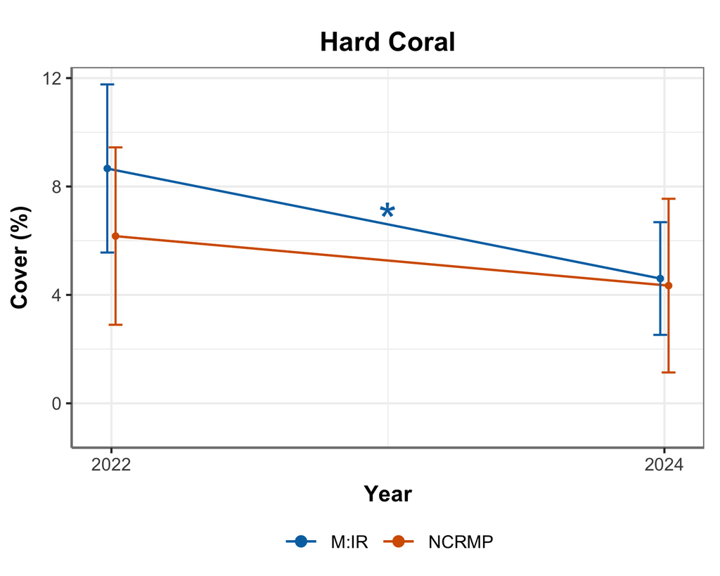

Figure 2. Cover estimates for main benthic groups inside and outside M:IR areas for 2022 and 2024. A black (+) indicates a significant difference between groups in that survey year (i.e., 2022 or 2024). A colored asterisk (*) indicates significance difference between years for the given group (i.e., M:IR or NCRMP). The category ‘Other’ comprises Cyanobacteria, Palythoa, *Millepora*, Seagrass, bare substrate, and other miscellaneous organisms.

**Macroalgae**

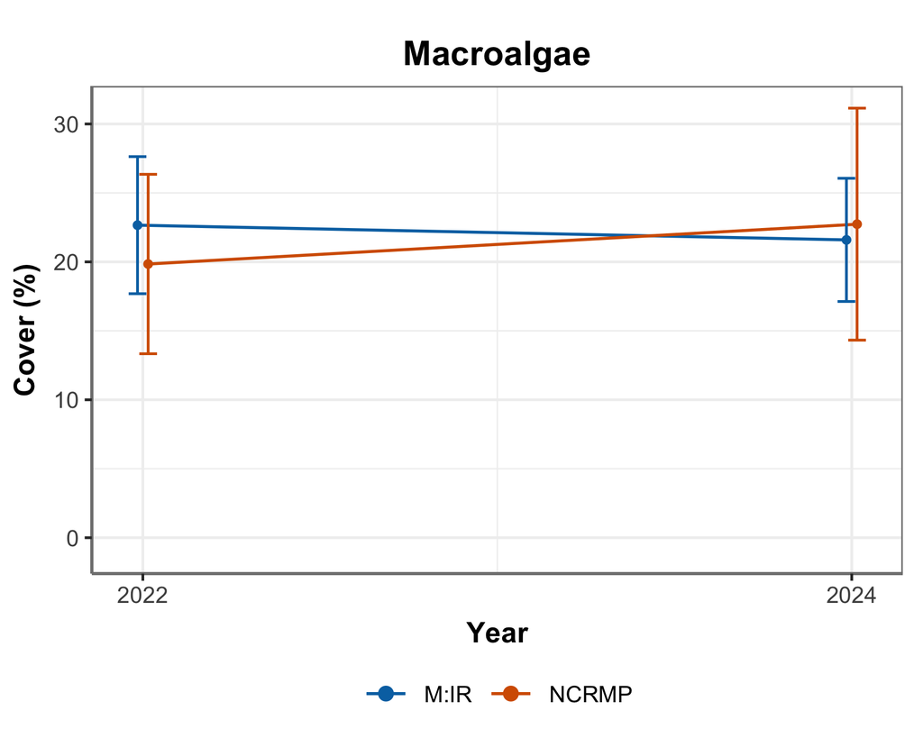

Figure 2. Cover estimates for main benthic groups inside and outside M:IR areas for 2022 and 2024. A black (+) indicates a significant difference between groups in that survey year (i.e., 2022 or 2024). A colored asterisk (*) indicates significance difference between years for the given group (i.e., M:IR or NCRMP). The category ‘Other’ comprises Cyanobacteria, Palythoa, *Millepora*, Seagrass, bare substrate, and other miscellaneous organisms.

**Octocoral**

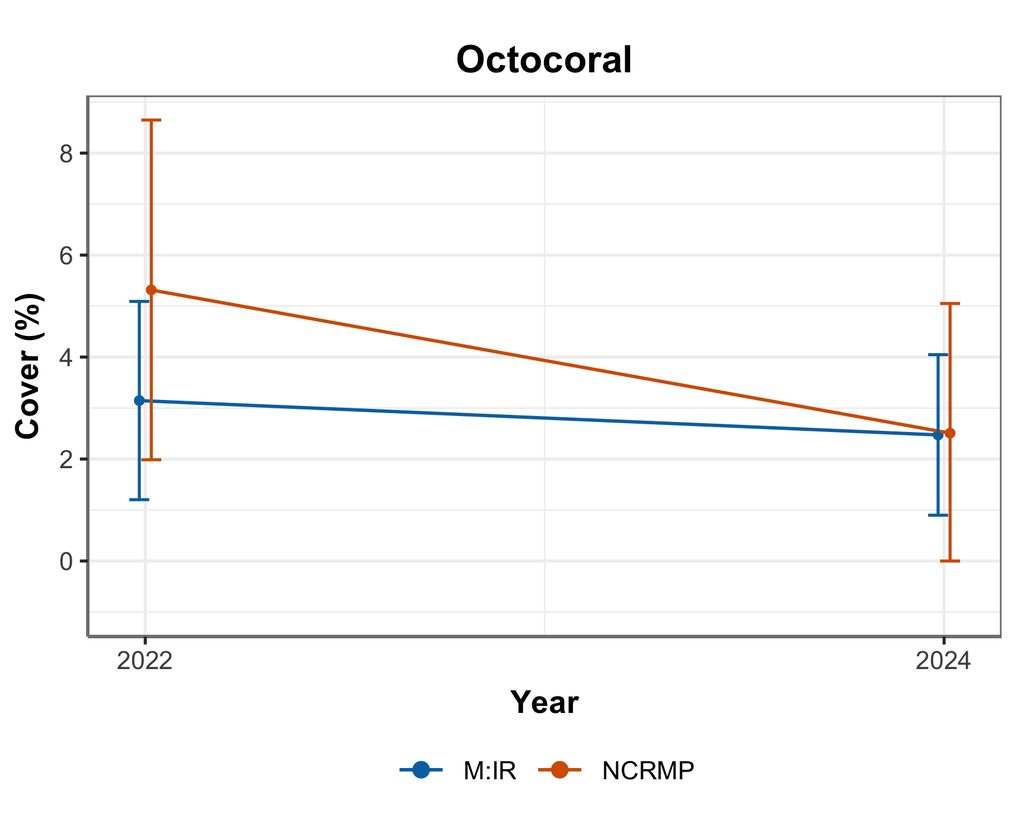

Figure 2. Cover estimates for main benthic groups inside and outside M:IR areas for 2022 and 2024. A black (+) indicates a significant difference between groups in that survey year (i.e., 2022 or 2024). A colored asterisk (*) indicates significance difference between years for the given group (i.e., M:IR or NCRMP). The category ‘Other’ comprises Cyanobacteria, Palythoa, *Millepora*, Seagrass, bare substrate, and other miscellaneous organisms.

**Sponge**

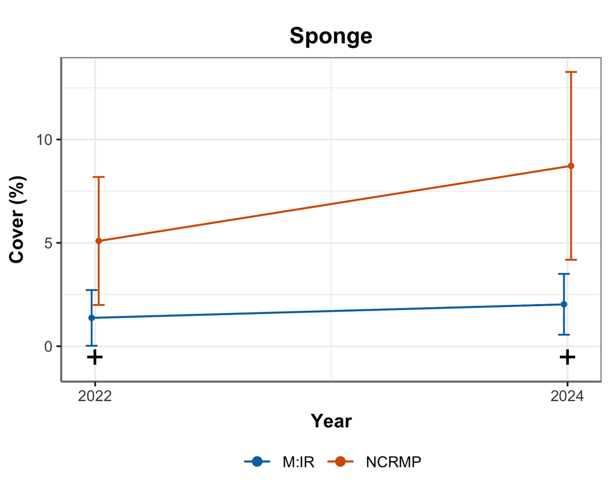

Figure 2. Cover estimates for main benthic groups inside and outside M:IR areas for 2022 and 2024. A black (+) indicates a significant difference between groups in that survey year (i.e., 2022 or 2024). A colored asterisk (*) indicates significance difference between years for the given group (i.e., M:IR or NCRMP). The category ‘Other’ comprises Cyanobacteria, Palythoa, *Millepora*, Seagrass, bare substrate, and other miscellaneous organisms.

**Turf Algae**

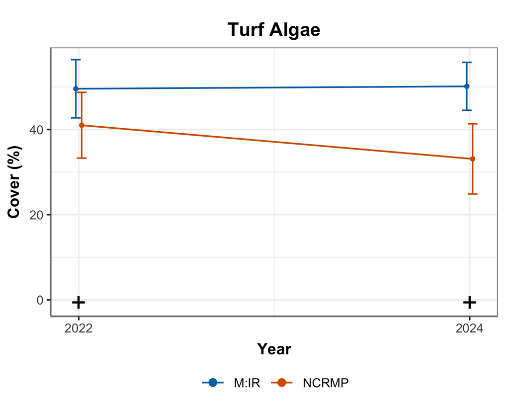

Figure 2. Cover estimates for main benthic groups inside and outside M:IR areas for 2022 and 2024. A black (+) indicates a significant difference between groups in that survey year (i.e., 2022 or 2024). A colored asterisk (*) indicates significance difference between years for the given group (i.e., M:IR or NCRMP). The category ‘Other’ comprises Cyanobacteria, Palythoa, *Millepora*, Seagrass, bare substrate, and other miscellaneous organisms.

**Crustose Coralline Algae (CCA)**

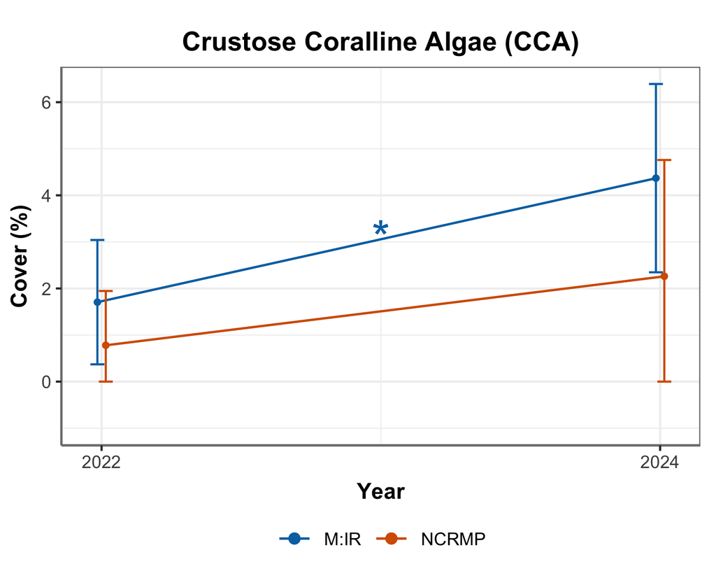

Figure 2. Cover estimates for main benthic groups inside and outside M:IR areas for 2022 and 2024. A black (+) indicates a significant difference between groups in that survey year (i.e., 2022 or 2024). A colored asterisk (*) indicates significance difference between years for the given group (i.e., M:IR or NCRMP). The category ‘Other’ comprises Cyanobacteria, Palythoa, *Millepora*, Seagrass, bare substrate, and other miscellaneous organisms.

**Ramicrusta**

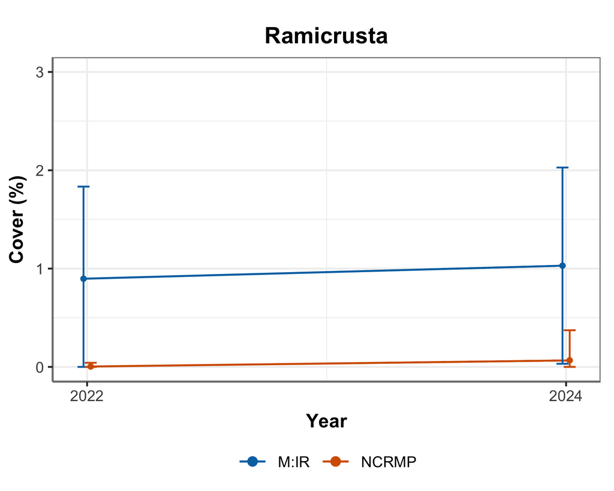

Figure 2. Cover estimates for main benthic groups inside and outside M:IR areas for 2022 and 2024. A black (+) indicates a significant difference between groups in that survey year (i.e., 2022 or 2024). A colored asterisk (*) indicates significance difference between years for the given group (i.e., M:IR or NCRMP). The category ‘Other’ comprises Cyanobacteria, Palythoa, *Millepora*, Seagrass, bare substrate, and other miscellaneous organisms.

**Other**

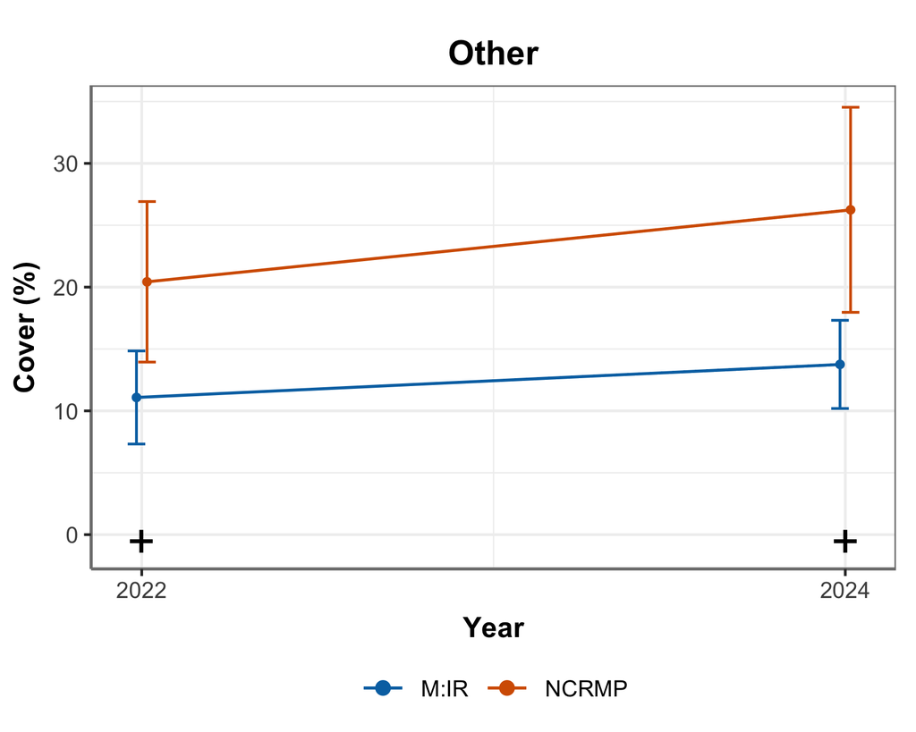

Figure 2. Cover estimates for main benthic groups inside and outside M:IR areas for 2022 and 2024. A black (+) indicates a significant difference between groups in that survey year (i.e., 2022 or 2024). A colored asterisk (*) indicates significance difference between years for the given group (i.e., M:IR or NCRMP). The category ‘Other’ comprises Cyanobacteria, Palythoa, *Millepora*, Seagrass, bare substrate, and other miscellaneous organisms.

## 4 Coral Demography

The following table summarizes the number of observations across all strata and survey years of each focal species and identifies the most abundant species encountered.

Table 4. Number of colonies observed for focal M:IR species and the most commonly encountered non-focal species in 2022 and 2024.

| **Species** | **Colonies in 2022** | **Colonies in 2024** |  |
| --- | --- | --- | --- |
| *Siderastrea siderea* | 3,868 | 5,618 |  |
| **Porites astreoides* | 2,657 | 2,132 |  |
| *Stephanocoenia intersepta* | 1,345 | 1,534 |  |
| *Agaricia agaricites* | 884 | 237 |  |
| *Porites porites* | 776 | 558 |  |
| **Montastraea cavernosa* | 437 | 645 |  |
| **Orbicella faveolata* | 266 | 237 |  |
| **Orbicella annularis* | 211 | 156 |  |
| *Siderastrea radians* | 182 | 328 |  |
| *Porites furcata* | 160 | 77 |  |
| *Porites divaricata* | 118 | 100 |  |
| *Dichocoenia stokesii* | 106 | 137 |  |
| **Colpophyllia natans* | 103 | 76 |  |
| *Solenastrea bournoni* | 79 | 113 |  |
| **Acropora cervicornis* | 74 | 13 |  |
| **Diploria labyrinthiformis* | 50 | 65 |  |
| **Pseudodiploria strigosa* | 50 | 46 |  |
| **Eusmilia fastigiata* | 45 | 75 |  |
| **Pseudodiploria clivosa* | 23 | 31 |  |
| **Acropora palmata* | 14 | 0 |  |
| **Meandrina meandrites* | 5 | 11 |  |
| * indicates M:IR focal species |  |  |  |

### 4.1 Focal Species

The stratified random surveys are designed to optimize sampling efficiency and provide high precision estimates of coral population metrics at relatively low sample sizes (Smith et al., 2011). The effectiveness of restoration can be quantified by comparison of these metrics between M:IR sites and similar habitats outside these restoration areas.

The following figures for these metrics are grouped by each focal species. Significant statistical differences using a two-tailed t-test are indicated for differences between survey years (2022 vs. 2024) and between areas (M:IR vs. NCRMP) for density, old mortality, and mean colony size. The size frequency figures illustrate the relative distribution of size classes for each species, providing insight into the population structure. Comparisons among size classes across years can reveal changes in demographic processes, such as growth, recruitment, and survival. In general, coral populations are expected to be dominated by smaller, younger colonies, with progressively fewer individuals observed in each larger size class.

**Acropora cervicornis**

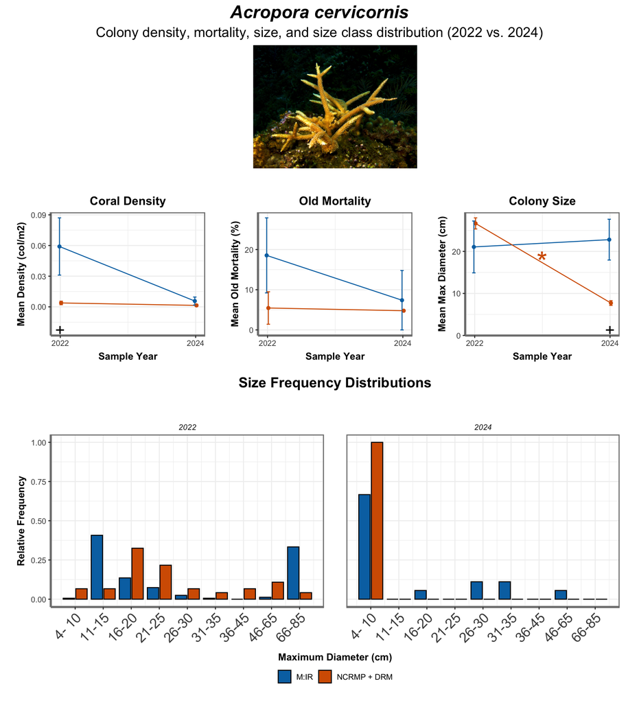

Figure 3. Coral density, old mortality, colony size, and size frequency distribution for focal M:IR species across sample years (2022 and 2024) and survey types (M:IR and NCRMP + DRM). A black plus (+) indicates a significant difference in estimates (i.e., density, mortality, or size) between groups in that survey year (i.e., 2022 or 2024). A colored asterisk (*) indicates significance between years for the given group (i.e., M:IR or NCRMP). Note: Y axis bounds vary by species.

**Acropora palmata**

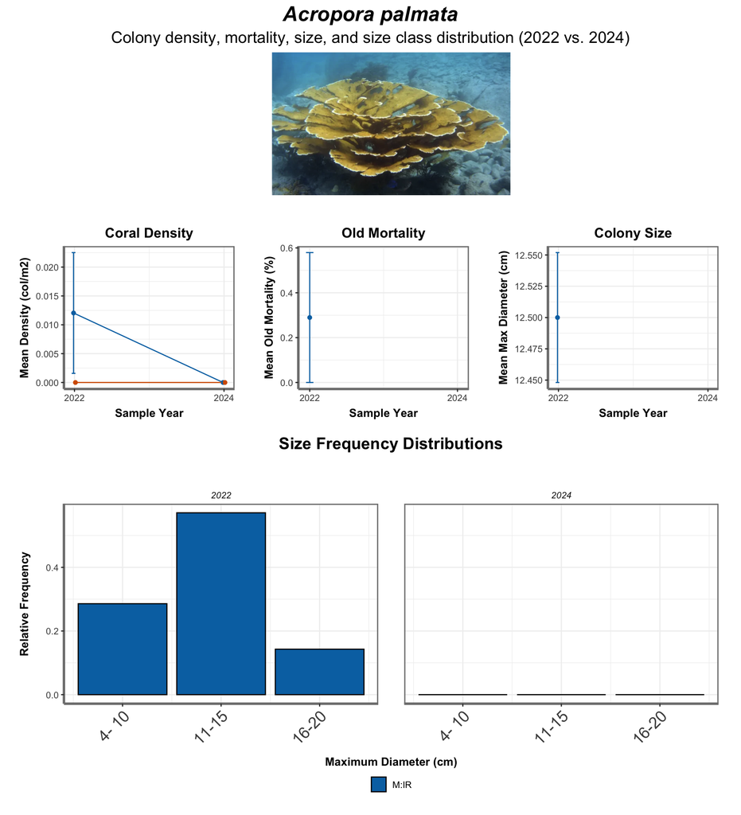

Figure 3. Coral density, old mortality, colony size, and size frequency distribution for focal M:IR species across sample years (2022 and 2024) and survey types (M:IR and NCRMP + DRM). A black plus (+) indicates a significant difference in estimates (i.e., density, mortality, or size) between groups in that survey year (i.e., 2022 or 2024). A colored asterisk (*) indicates significance between years for the given group (i.e., M:IR or NCRMP). Note: Y axis bounds vary by species.

**Colpophyllia natans**

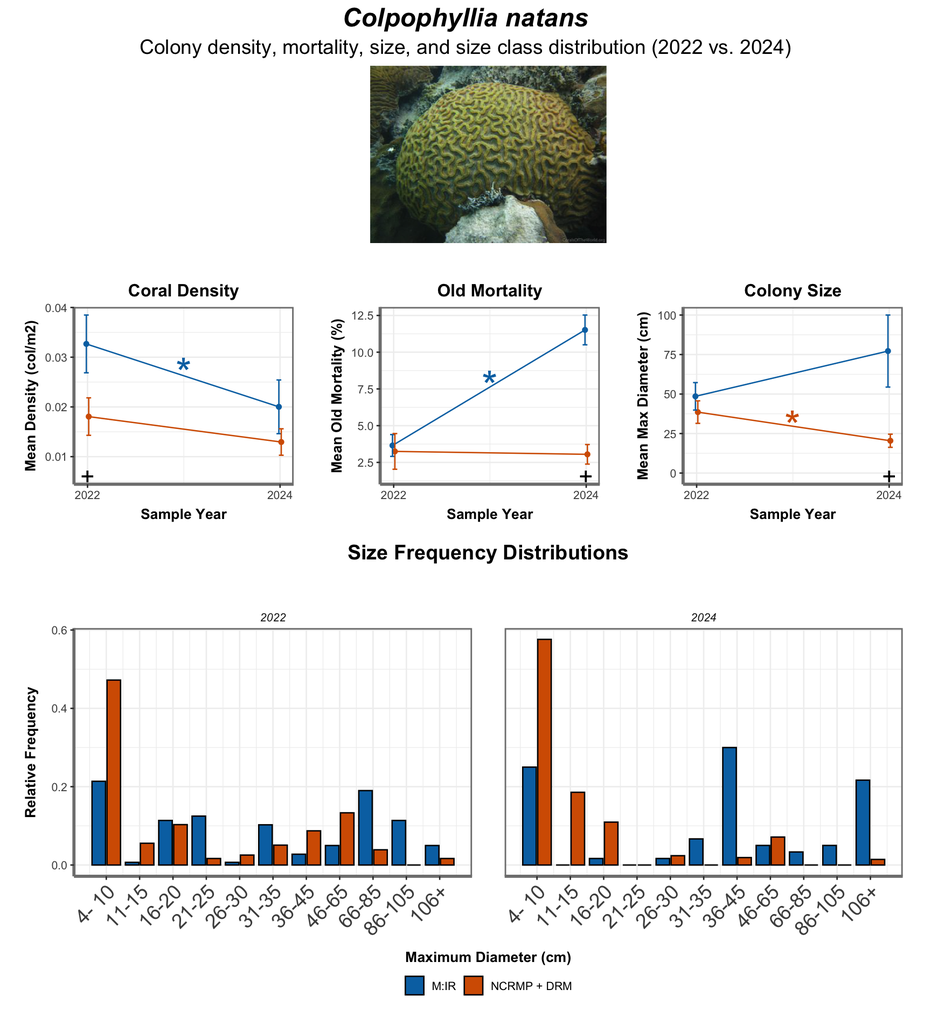

Figure 3. Coral density, old mortality, colony size, and size frequency distribution for focal M:IR species across sample years (2022 and 2024) and survey types (M:IR and NCRMP + DRM). A black plus (+) indicates a significant difference in estimates (i.e., density, mortality, or size) between groups in that survey year (i.e., 2022 or 2024). A colored asterisk (*) indicates significance between years for the given group (i.e., M:IR or NCRMP). Note: Y axis bounds vary by species.

**Diploria labyrinthiformis**

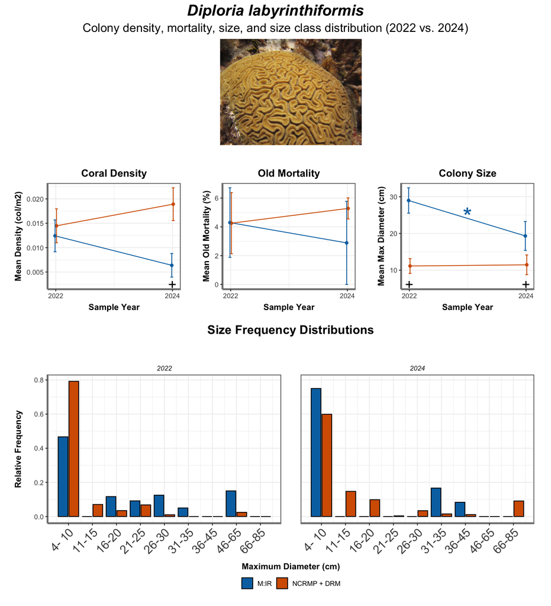

Figure 3. Coral density, old mortality, colony size, and size frequency distribution for focal M:IR species across sample years (2022 and 2024) and survey types (M:IR and NCRMP + DRM). A black plus (+) indicates a significant difference in estimates (i.e., density, mortality, or size) between groups in that survey year (i.e., 2022 or 2024). A colored asterisk (*) indicates significance between years for the given group (i.e., M:IR or NCRMP). Note: Y axis bounds vary by species.

**Eusmilia fastigiata**

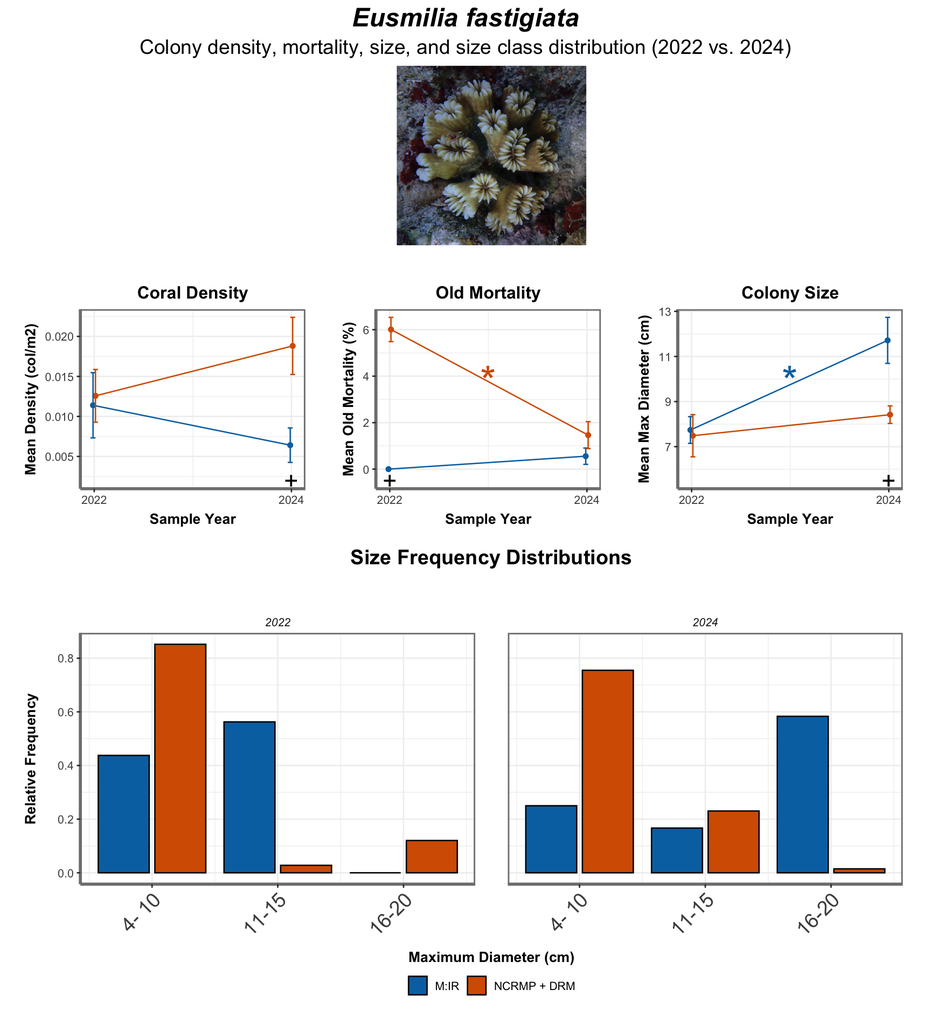

Figure 3. Coral density, old mortality, colony size, and size frequency distribution for focal M:IR species across sample years (2022 and 2024) and survey types (M:IR and NCRMP + DRM). A black plus (+) indicates a significant difference in estimates (i.e., density, mortality, or size) between groups in that survey year (i.e., 2022 or 2024). A colored asterisk (*) indicates significance between years for the given group (i.e., M:IR or NCRMP). Note: Y axis bounds vary by species.

**Meandrina meandrites**

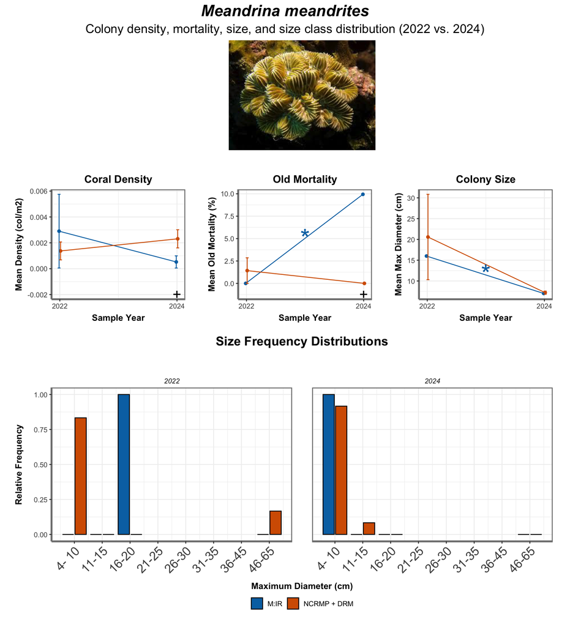

Figure 3. Coral density, old mortality, colony size, and size frequency distribution for focal M:IR species across sample years (2022 and 2024) and survey types (M:IR and NCRMP + DRM). A black plus (+) indicates a significant difference in estimates (i.e., density, mortality, or size) between groups in that survey year (i.e., 2022 or 2024). A colored asterisk (*) indicates significance between years for the given group (i.e., M:IR or NCRMP). Note: Y axis bounds vary by species.

**Orbicella annularis**

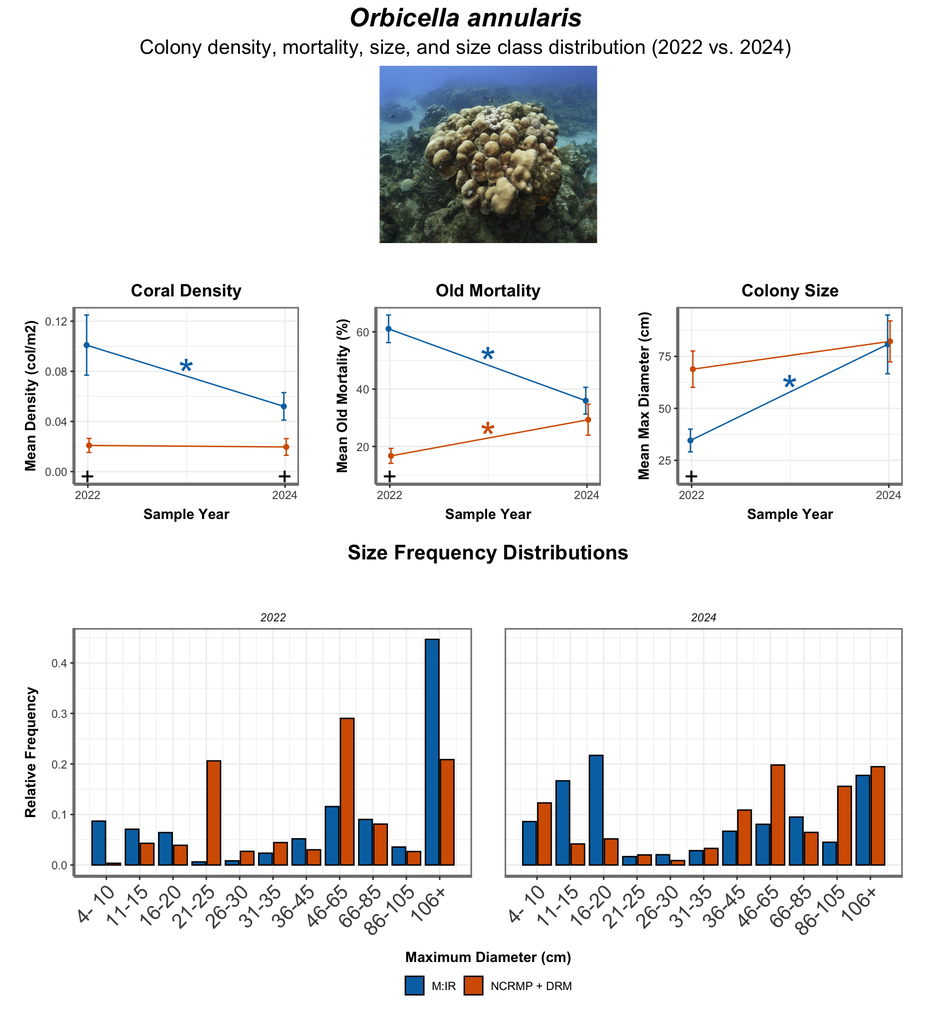

Figure 3. Coral density, old mortality, colony size, and size frequency distribution for focal M:IR species across sample years (2022 and 2024) and survey types (M:IR and NCRMP + DRM). A black plus (+) indicates a significant difference in estimates (i.e., density, mortality, or size) between groups in that survey year (i.e., 2022 or 2024). A colored asterisk (*) indicates significance between years for the given group (i.e., M:IR or NCRMP). Note: Y axis bounds vary by species.

**Orbicella faveolata**

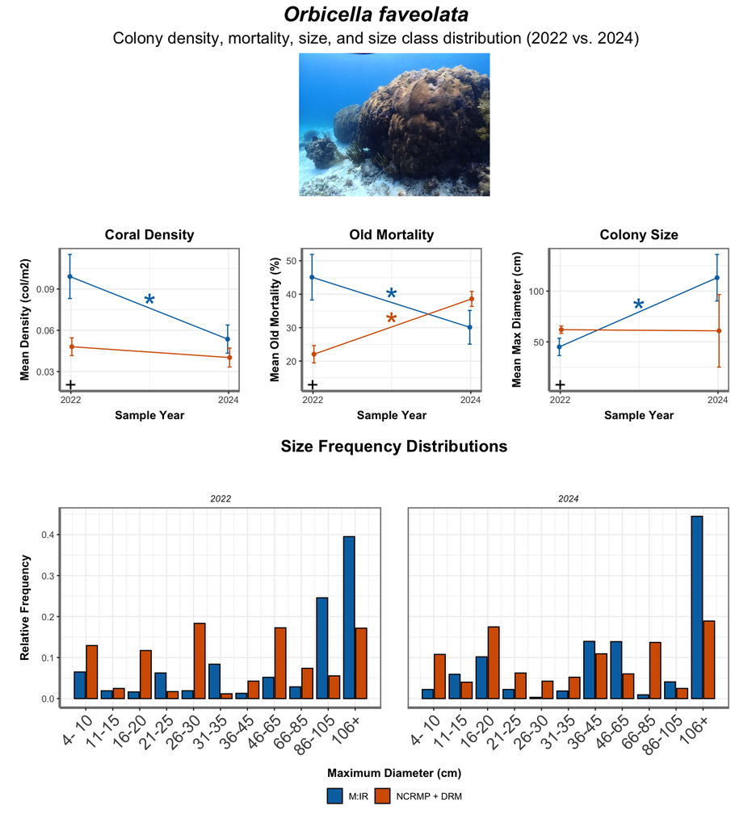

Figure 3. Coral density, old mortality, colony size, and size frequency distribution for focal M:IR species across sample years (2022 and 2024) and survey types (M:IR and NCRMP + DRM). A black plus (+) indicates a significant difference in estimates (i.e., density, mortality, or size) between groups in that survey year (i.e., 2022 or 2024). A colored asterisk (*) indicates significance between years for the given group (i.e., M:IR or NCRMP). Note: Y axis bounds vary by species.

**Porites astreoides**

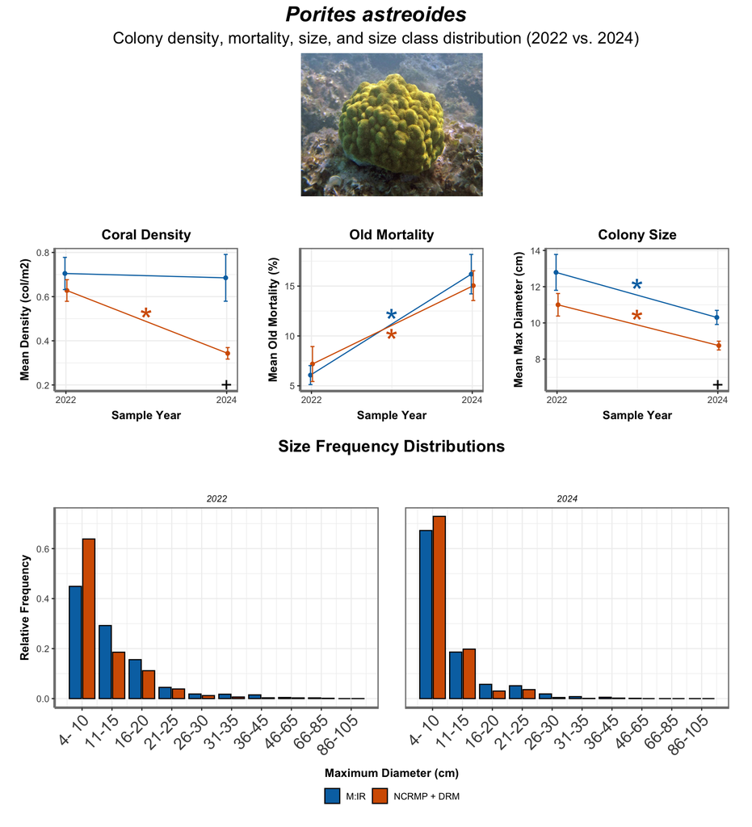

Figure 3. Coral density, old mortality, colony size, and size frequency distribution for focal M:IR species across sample years (2022 and 2024) and survey types (M:IR and NCRMP + DRM). A black plus (+) indicates a significant difference in estimates (i.e., density, mortality, or size) between groups in that survey year (i.e., 2022 or 2024). A colored asterisk (*) indicates significance between years for the given group (i.e., M:IR or NCRMP). Note: Y axis bounds vary by species.

**Pseudodiploria clivosa**

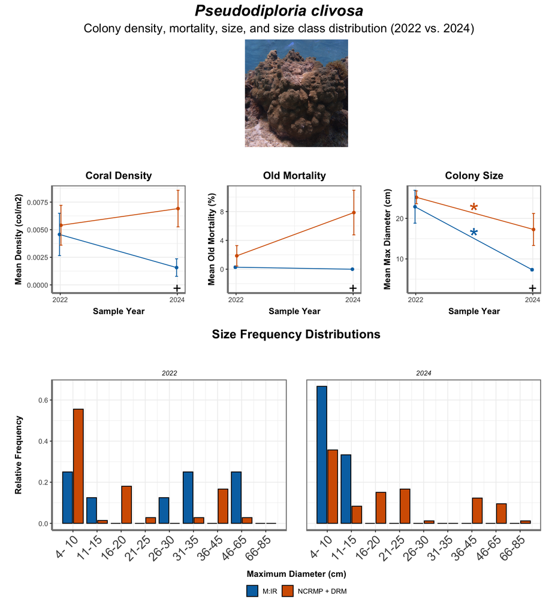

Figure 3. Coral density, old mortality, colony size, and size frequency distribution for focal M:IR species across sample years (2022 and 2024) and survey types (M:IR and NCRMP + DRM). A black plus (+) indicates a significant difference in estimates (i.e., density, mortality, or size) between groups in that survey year (i.e., 2022 or 2024). A colored asterisk (*) indicates significance between years for the given group (i.e., M:IR or NCRMP). Note: Y axis bounds vary by species.

**Pseudodiploria strigosa**

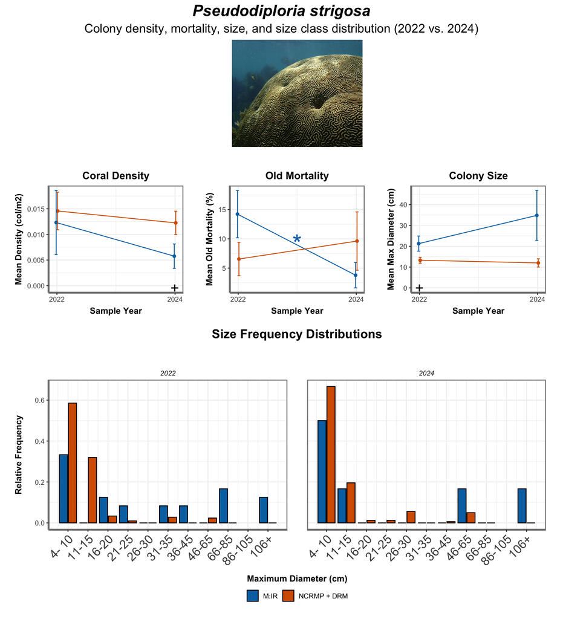

Figure 3. Coral density, old mortality, colony size, and size frequency distribution for focal M:IR species across sample years (2022 and 2024) and survey types (M:IR and NCRMP + DRM). A black plus (+) indicates a significant difference in estimates (i.e., density, mortality, or size) between groups in that survey year (i.e., 2022 or 2024). A colored asterisk (*) indicates significance between years for the given group (i.e., M:IR or NCRMP). Note: Y axis bounds vary by species.

**Montastraea cavernosa**

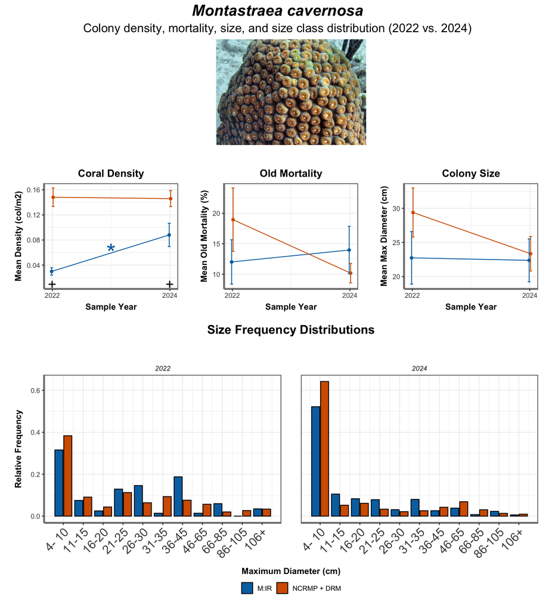

Figure 3. Coral density, old mortality, colony size, and size frequency distribution for focal M:IR species across sample years (2022 and 2024) and survey types (M:IR and NCRMP + DRM). A black plus (+) indicates a significant difference in estimates (i.e., density, mortality, or size) between groups in that survey year (i.e., 2022 or 2024). A colored asterisk (*) indicates significance between years for the given group (i.e., M:IR or NCRMP). Note: Y axis bounds vary by species.

### 4.2 Coral Density

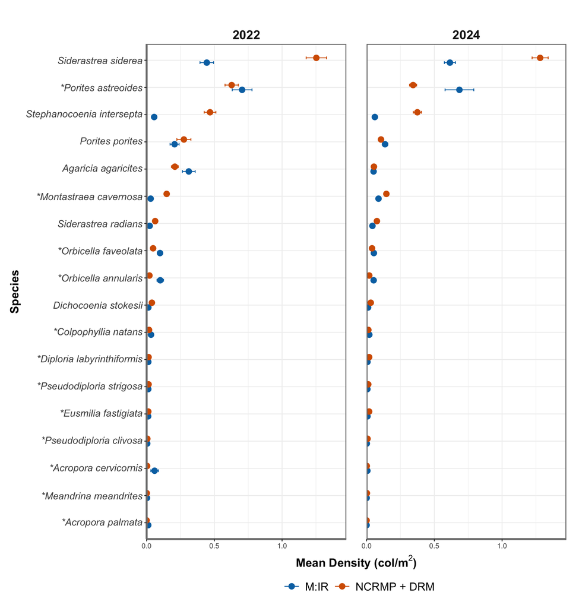

Figure 4. Species-specific coral density (colonies/m<sup>2</sup>) ± SEM outside (NCRMP + DRM) and inside M:IR areas in 2022 and 2024. Focal M:IR species are denoted with a (*).

### 4.3 Old Mortality

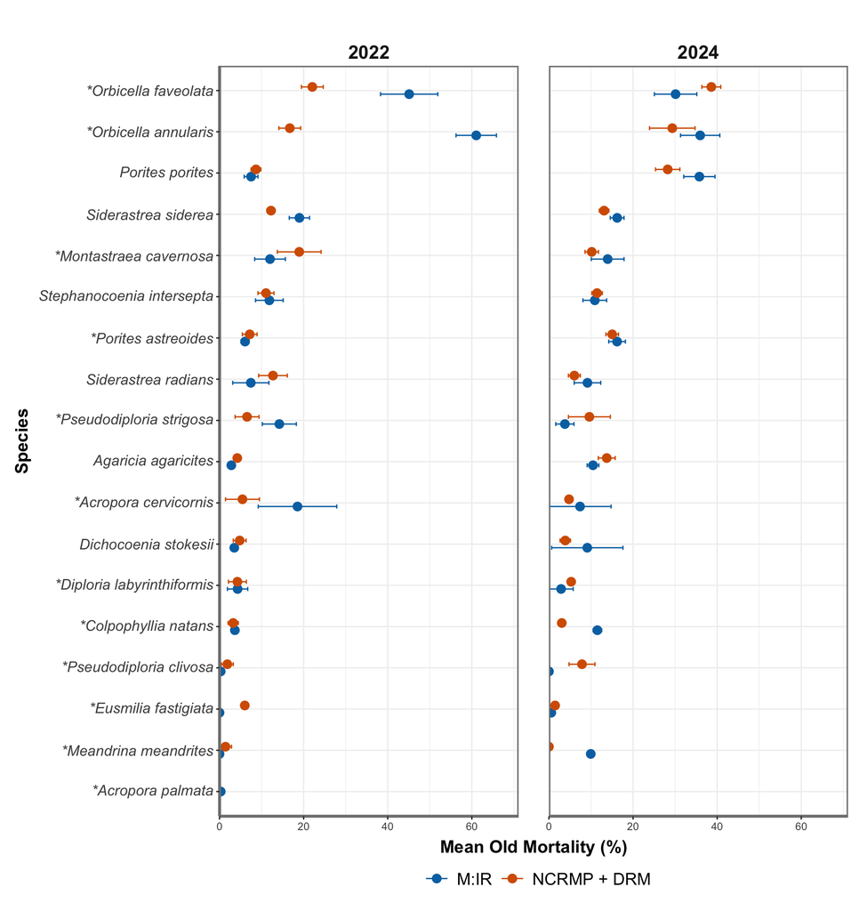

Figure 5. Percent old mortality ± SEM by coral species outside (NCRMP + DRM) and inside M:IR areas in 2022 and 2024. Focal M:IR species are denoted with a (*).

### 4.4 Colony Size

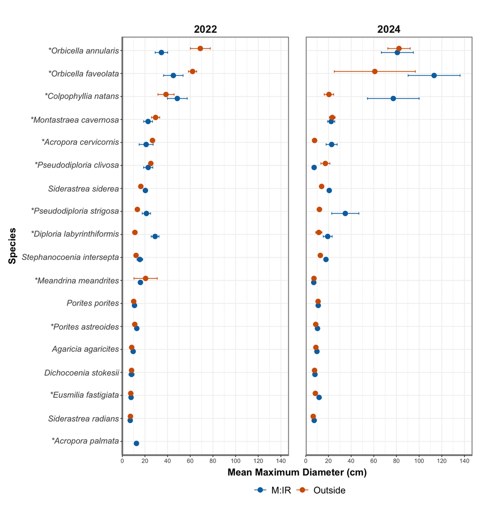

Figure 6. Colony size (maximum diameter (cm) ± SEM by coral species outside (NCRMP + DRM) and inside M:IR areas in 2022 and 2024. Focal M:IR species are denoted with a (*).

### 4.5 Bleaching Prevalence

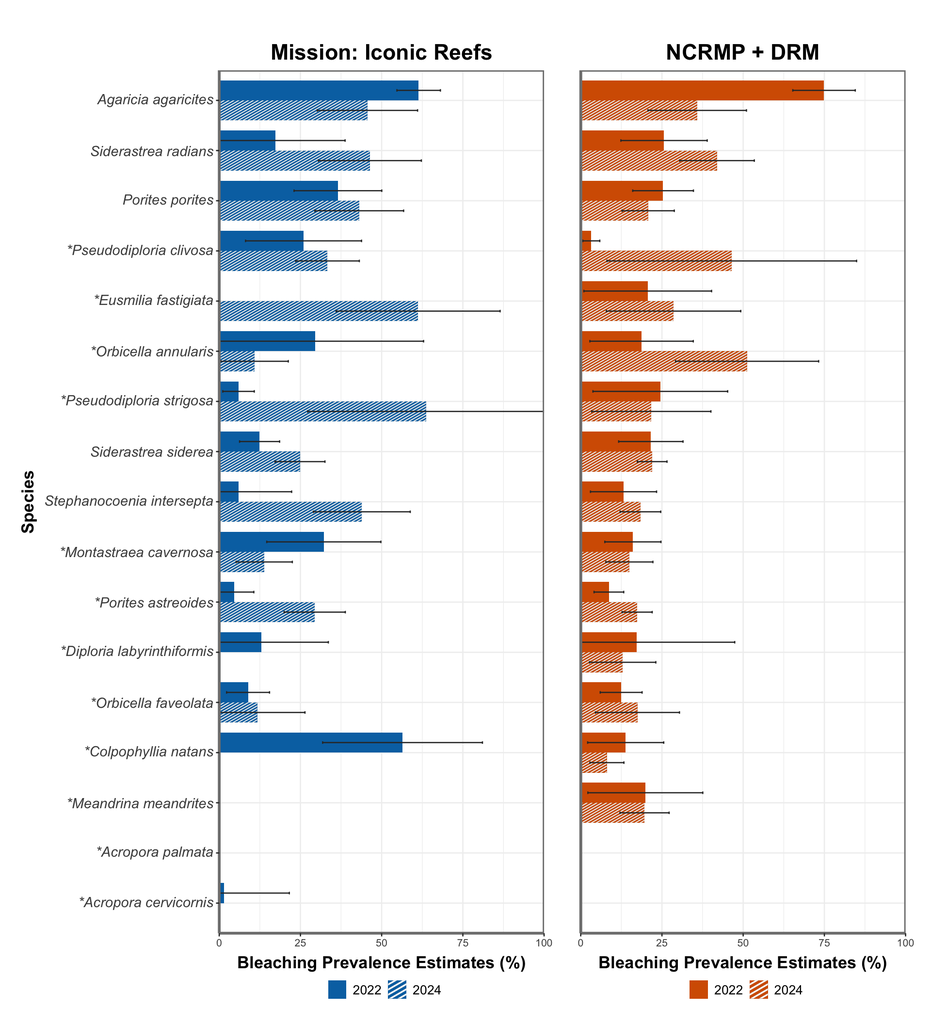

Figure 7. Species-specific bleaching prevalence estimates (% ± SEM) observed outside (NCRMP + DRM) and inside M:IR areas. Focal M:IR species are denoted with a (*).

### 4.6 Disease Prevalence

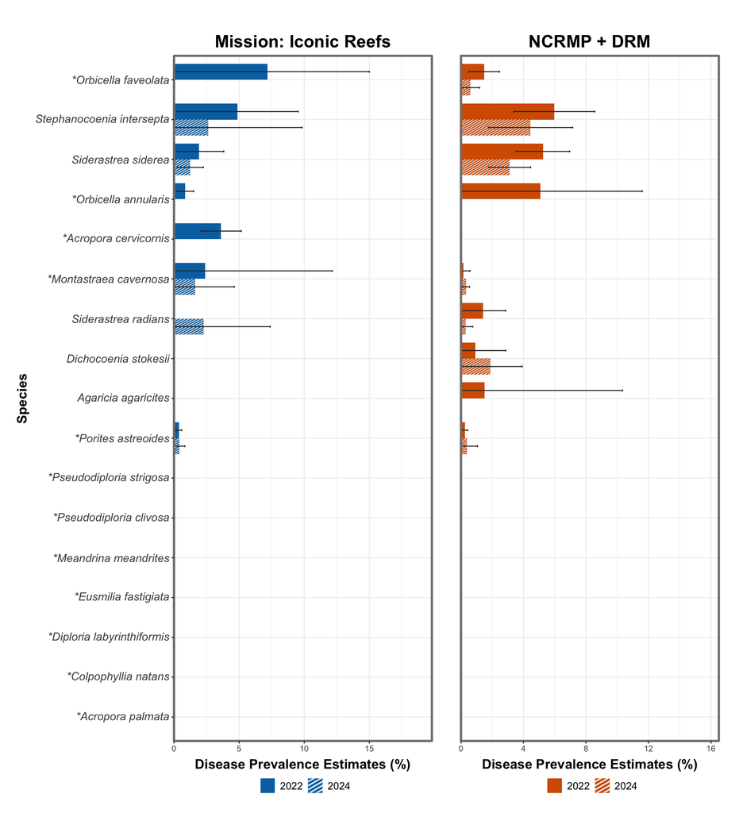

Figure 8. Species-specific disease prevalence estimates (% ± SEM) observed outside (NCRMP + DRM) and inside M:IR areas. Focal M:IR species are denoted with a (*).

## 5 Point of Contact

*NCRMP Atlantic Benthic Team Lead:* **Shay Viehman** (shay.viehman@noaa.gov)

## 6 References

Ault, J. S., Smith, S. G., Luo, J., Grove, L. J., Johnson, M. W., & Blondeau, J. (2021). *Refinement of the Southern Florida Reef Tract Benthic Habitat Map with Habitat Use Patterns of Reef Fish Species* [Dataset]. NOAA National Centers for Environmental Information. https://www.ncei.noaa.gov/archive/accession/0224176

Blondeau, J. B., Grove, J., & Harper, R. (2025). *Mission: Iconic Reefs RVC Analysis*. NOAA Coral Reef Conservation Program.

Goergen, E. A., Schopmeyer, S., Moulding, A. L., & Moura, A. (2020). *Coral Reef Restoration Monitoring Guide: Methods to evaluate restoration success from local to ecosystem scales* (Technical Report NOS NCCOS 279). National Oceanic; Atmospheric Administration. https://doi.org/10.25923/xndz-h538

Grove, L. J. W., Viehman, T. S., Blondeau, J., Cain, E., Edwards, K. F., Krampitz, N., Langwiser, C., Mateski, J., Sturm, A. B., Swanson, D., & Towle, E. K. (in prep). *National Coral Reef Monitoring Program, Biological Monitoring Summary – Florida: 2024* [Technical Memorandum NOS CRCP, in preparation]. NOAA.

Groves, S., Mateski, J., Krampitz, N., Sturm, A. M., & Viehman, T. S. (2025). *NCRMP benthics statistical package in R (website)*. R package version 1.0.0. https://github.com/MSE-NCCOS-NOAA/NCRMP_benthics

NOAA Coral Reef Conservation Program (CRCP). (2024a). *National Coral Reef Monitoring Program (NCRMP) Benthic Community Assessment Survey Field Protocols for U.S. Atlantic: Florida, Flower Garden Banks, Puerto Rico, and U.S. Virgin Islands* (p. 29). NOAA Coral Reef Conservation Program. https://doi.org/10.25923/e3gf-vk84

NOAA Coral Reef Conservation Program (CRCP). (2024b). *National Coral Reef Monitoring Program (NCRMP) Coral Demographics Survey Field Protocols for U.S. Atlantic: Florida, Flower Garden Banks, Puerto Rico, and U.S. Virgin Islands* (p. 28). NOAA Coral Reef Conservation Program. https://doi.org/10.25923/hgpr-jm80

NOAA Coral Reef Conservation Program (NOAA CRCP). (2022a). *National Coral Reef Monitoring Program (NCRMP) Benthic Community Assessment Survey Field Protocols for U.S. Atlantic: Florida, Flower Garden Banks, Puerto Rico, and U.S. Virgin Islands–2022*. NOAA Coral Reef Conservation Program. https://doi.org/10.25923/0708-8333

NOAA Coral Reef Conservation Program [NOAA]. (2022b). *National Coral Reef Monitoring Program (NCRMP) Coral Demographics Survey Field Protocols for U.S. Atlantic: Florida, Flower Garden Banks, Puerto Rico, and U.S. Virgin Islands–2022*. NOAA Coral Reef Conservation Program. https://doi.org/10.25923/9a1r-m911

NOAA National Marine Fisheries Service. (2014). Endangered and Threatened Wildlife and Plants: Final Listing Determinations on Proposal to List 66 Reef-Building Coral Species and to Reclassify Elkhorn and Staghorn Corals. *Federal Register*, *79*(175), 53851–54123.

Smith, S. G., Swanson, D. W., Chiappone, M., Miller, S. L., & Ault, J. S. (2011). Probability sampling of stony coral populations in the florida keys. *Environmental Monitoring and Assessment*, *183*(1–4), 121–138. https://doi.org/10.1007/s10661-011-1912-2

Viehman, T. S., Grove, J. G., Blondeau, J., Cain, E., Edwards, K. F., Groves, S. H., Krampitz, N., Langwiser, C., Siceloff, L., Swanson, D., Towle, E. K., & Williams, B. (2023). *National Coral Reef Monitoring Program, Biological Monitoring Summary – Florida: 2022* [Technical Memorandum NOS CRCP 48]. NOAA. https://doi.org/10.25923/e6xg-1989

**Data Sources:**

NOAA National Centers for Coastal Ocean Science; NOAA Southeast Fisheries Science Center (2024). National Coral Reef Monitoring Program: Assessment of coral reef benthic communities in Florida [2022, 2024]. NOAA National Centers for Environmental Information. Dataset. doi: 10.7289/v5xw4h4z

Florida Fish and Wildlife Conservation Commission’s Disturbance Response Monitoring ([DRM](https://coraldrm.org/))